# Morfologia, luento 9

Juho Härme

Pinni B 5004, juho.harme@uta.fi

# Sijat funktionaalisen morfologian kannalta 3

Tehtävä: Miten (ei milloin) elollisuuskategoria ilmenee / mihin vaikuttaa?

# Milloin elollisuuskategoria ilmenee?

- Mikä on elollista?
- *living organisms…*
- *maintain homeostasis, are composed of cells, undergo metabolism, can grow, adapt to their environment, respond to stimuli, and reproduce.*

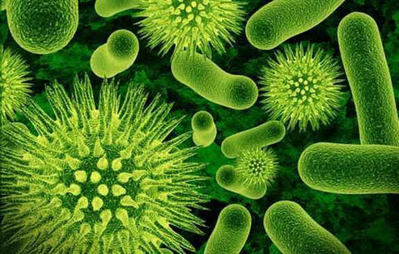

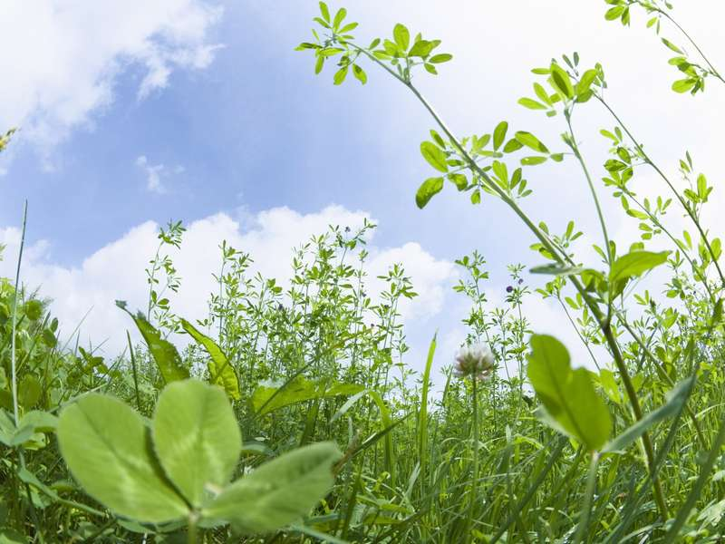

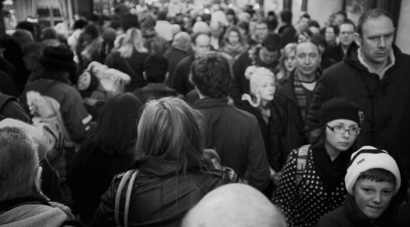

[figure not shown]

[figure not shown]

# Muuta akkusatiivista

- Paikka + aika – miten?

# Paikka ja aika

- Пришли *на работу*, а потом пошли пообедать
- Российская делегация прибыла *в Стамбул* с намерением способствовать дальнейшему укреплению связей с Организацией Исламская конференция
- Дурно пахнущие юноши из “группы поддержки”, стоявшие возле меня, поспешно выскочили за дверь в коридор.
- К вечеру Сергей пришёл под окно с саксофоном
- *В вечер* моего дебюта в ложе дирекции находился Михаил Иванович Чулаки.
- Премьер Яценюк вместе с министрами *всю неделю* ходил по парламентским фракциям.
- он приглашает меня *на месяц* в Ялту.
- Зато *под утро* я заснул как убитый и пробудился в половине двенадцатого.

# Törmätä, osua

- Если не помогает этот приём, попробуйте стукнуть лбом ___________.
- Как будто разбиться *о землю* хуже, чем сгореть в танке?
- Я долго вытирал ботинки *о траву* и промочил их насквозь.

# Instrumentaali

- жарить над раскалёнными углями.
- встанете *перед картиной* и будете думать: “Так… вот она, это же она…”
- Под пиджаком у него была только рваная сетчатая майка
- Почему-то я вспомнил, как мы шли сквером и спорили
- Кругом золотились осенние поля, мы шли дорогой, по которой…
- Он шёл лесом, и ему представлялось: вот уж нет его…
- перед сном / рассветом / тем, как…
- утром, вечером, днём, летом, зимой, целыми вечерами
- прошлой ночью, следующей ночью, прошлой осенью..

# Mikä merkitys?

- Мы видели канал, покрытый льдом.
- Таким образом, профилактика экстремизма, проводимая государством, нарушает права человека и должна быть признана неконституционной - Квартиры, которые у нас строятся *компанией* «Стройметресурс», отличаются хорошей планировкой.
- Ветром унесло лодку
- Тротуар залило водой